# habshd_individual_prs

Which individual PRSs associate with cognitive impairment?

## Setup

main input master_rds <- “/wynton/group/andrews/users/rakshyasharma/PRS/shared_data/habshd_master_df.rds”

required input columns IID cognitive_impairment ID_Gender Age Race APOE4_Positivity PC1, PC2, PC3, PC4

Medication variables: taking_cholesterol_meds taking_diabetes_meds taking_hypertension_meds

Clinical / phenotype variables: BW_CholTotal BW_LDLchol BW_HDLChol BW_Triglycerides BW_HbA1c OM_BMI OM_BP_DIA OM_BP_SYS Pulse_Pressure CDX_Depression CDX_Hypertension CDX_Diabetes AUDIT_Total SocialSupport_Total IMH_TBI Smoke Vision_Loss Hearing_Loss GDS_Category

PRS variables: bmi_score education_score alcohol_drinking_weekly_score smoking_initiation_score diabetes_score diastolic_blood_pressure_score systolic_blood_pressure_score pulse_pressure_score total_cholesterol_score social_isolation_score Hearing_Loss_score Vision_Loss_score Triglycerides_score HDL_Cholesterol_score LDL_Cholesterol_score Physical_Activity_score Major_Depressive_Disorder_score

cognitive_impairment ~ PRS + Age + APOE4_Positivity + PC1 + PC2 + PC3 + PC4 + Race

(ID_gender) for total model

output

results/ ├── rds/ │ ├── habshd_individual_prs_analytic_dataset.rds │ ├── habshd_individual_prs_results.rds │ └── habshd_individual_prs_sample_sizes.rds │ ├── tables/ │ ├── habshd_individual_prs_baseline_table1.docx │ ├── habshd_individual_prs_baseline_table1.rtf │ ├── habshd_individual_prs_baseline_table1.html │ ├── habshd_individual_prs_results.csv │ ├── habshd_individual_prs_results.html │ ├── habshd_individual_prs_sample_sizes.csv │ ├── habshd_individual_prs_sample_sizes.html │ └── habshd_individual_prs_results.xlsx │ └── figures/ ├── habshd_individual_prs_total.png └── habshd_individual_prs_by_sex.png

```r
.libPaths("/wynton/home/andrews/rakshyasharma/R/rocky8-x86_64-pc-linux-gnu-library/4.4-CBI-gcc13/")

library(readr)
library(dplyr)
```

```r
library(tidyr)
library(purrr)
library(broom)
library(ggplot2)
library(gt)
library(gtsummary)
library(data.table)
library(readxl)
library(stringr)
library(flextable)
library(openxlsx)

options(dplyr.summarise.inform = FALSE)
theme_set(theme_minimal(base_size = 12, base_family = "Arial"))
```

```r
master_rds <- "/wynton/group/andrews/users/rakshyasharma/PRS/shared_data/habshd_master_df.rds"

out_dir <- "results"
out_fig_dir <- file.path(out_dir, "figures")
out_tbl_dir <- file.path(out_dir, "tables")
out_rds_dir <- file.path(out_dir, "rds")

dir.create(out_fig_dir, recursive = TRUE, showWarnings = FALSE)
dir.create(out_tbl_dir, recursive = TRUE, showWarnings = FALSE)
dir.create(out_rds_dir, recursive = TRUE, showWarnings = FALSE)
```

## Helper functions

```r
check_required_columns <- function(df, required_cols) {
  missing_cols <- setdiff(required_cols, names(df))
  if (length(missing_cols) > 0) {
    stop(
      paste(
        "The master dataset is missing required columns:",
        paste(missing_cols, collapse = ", ")
      )
    )
  }
}
```

## Load master dataset

```r
final_df <- readRDS(master_rds) %>%
  dplyr::mutate(
    IID = as.character(IID),
    APOE4_Positivity = as.integer(APOE4_Positivity),
    APOE4_Positivity = ifelse(APOE4_Positivity %in% c(0, 1), APOE4_Positivity, NA_integer_),
    Sex = factor(ID_Gender, levels = c(0, 1), labels = c("Male", "Female")),
    RAPA_1_Scores = ifelse(RAPA_1_Total > 6, "High Score", "Low Score"),
    RAPA_2_Scores = ifelse(RAPA_2_Total > 2, "High Score", "Low Score")
  ) %>%
  dplyr::filter(!is.na(APOE4_Positivity))

required_cols <- c(
  "IID", "cognitive_impairment", "ID_Gender", "Sex", "Age", "Race",
  "APOE4_Positivity", "PC1", "PC2", "PC3", "PC4",
  "taking_cholesterol_meds", "taking_diabetes_meds", "taking_hypertension_meds",
  "BW_CholTotal", "BW_LDLchol", "BW_HDLChol", "BW_Triglycerides", "BW_HbA1c",
  "OM_BMI", "OM_BP_DIA", "OM_BP_SYS", "Pulse_Pressure",
  "CDX_Depression", "CDX_Hypertension", "CDX_Diabetes",
  "AUDIT_Total", "SocialSupport_Total", "IMH_TBI",
  "Smoke", "Vision_Loss", "Hearing_Loss",
  "RAPA_1_Scores", "RAPA_2_Scores", "GDS_Category",
  "bmi_score", "education_score", "alcohol_drinking_weekly_score",
  "smoking_initiation_score", "diabetes_score",
  "diastolic_blood_pressure_score", "systolic_blood_pressure_score",
  "pulse_pressure_score", "total_cholesterol_score",
  "social_isolation_score", "Hearing_Loss_score", "Vision_Loss_score",
  "Triglycerides_score", "HDL_Cholesterol_score", "LDL_Cholesterol_score",
  "Physical_Activity_score", "Major_Depressive_Disorder_score"
)

check_required_columns(final_df, required_cols)

cat("Analytic dataset rows:", nrow(final_df), "\n")
```

```
## Analytic dataset rows: 3207
```

```r
cat("Analytic dataset columns:", ncol(final_df), "\n")
```

```
## Analytic dataset columns: 1692
```

```r
cat("Cognitive impairment counts:\n")
```

```
## Cognitive impairment counts:
```

```r
print(table(final_df$cognitive_impairment, useNA = "ifany"))
```

```
##
##    0    1
## 2344  863
```

```r
cat("Sex by cognitive impairment:\n")
```

```
## Sex by cognitive impairment:
```

```r
print(table(final_df$Sex, final_df$cognitive_impairment, useNA = "ifany"))
```

```
##
##             0    1
##   Male    813  413
##   Female 1531  450
```

## Individual PRS association models

```r
prs_vars <- c(
  "bmi_score",
  "education_score",
  "alcohol_drinking_weekly_score",
  "smoking_initiation_score",
  "diabetes_score",
  "diastolic_blood_pressure_score",
  "systolic_blood_pressure_score",
  "pulse_pressure_score",
  "total_cholesterol_score",
  "social_isolation_score",
  "Hearing_Loss_score",
  "Vision_Loss_score",
  "Triglycerides_score",
  "HDL_Cholesterol_score",
  "LDL_Cholesterol_score",
  "Physical_Activity_score",
  "Major_Depressive_Disorder_score"
)

prs_label_map <- c(
  "bmi_score" = "BMI",
  "education_score" = "Education",
  "alcohol_drinking_weekly_score" = "Alcohol Consumption (weekly)",
  "smoking_initiation_score" = "Smoking Initiation",
  "diabetes_score" = "Type 2 Diabetes",
  "diastolic_blood_pressure_score" = "Diastolic Blood Pressure",
  "systolic_blood_pressure_score" = "Systolic Blood Pressure",
  "pulse_pressure_score" = "Pulse Pressure",
  "total_cholesterol_score" = "Total Cholesterol",
  "social_isolation_score" = "Social Isolation",
  "Hearing_Loss_score" = "Hearing Loss",
  "Vision_Loss_score" = "Vision Loss",
  "Triglycerides_score" = "Triglycerides",
  "HDL_Cholesterol_score" = "HDL Cholesterol",
  "LDL_Cholesterol_score" = "LDL Cholesterol",
  "Physical_Activity_score" = "Physical Activity",
  "Major_Depressive_Disorder_score" = "Major Depressive Disorder"
)

fit_habs_prs <- function(data, prs_var, sex_group = "Total", include_sex = TRUE) {
  covars <- c("Age", "APOE4_Positivity", "PC1", "PC2", "PC3", "PC4", "Race")
  if (include_sex) covars <- c(covars, "ID_Gender")

  form <- as.formula(
    paste("cognitive_impairment ~", paste(c(prs_var, covars), collapse = " + "))
  )

  fit <- glm(form, data = data, family = binomial())

  coef_tab <- summary(fit)$coefficients
  zval <- qnorm(0.975)

  if (!(prs_var %in% rownames(coef_tab))) {
    return(tibble(
      prs_var = prs_var,
      sex_strata = sex_group,
      estimate = NA_real_,
      std.error = NA_real_,
      statistic = NA_real_,
      p.value = NA_real_,
      conf.low = NA_real_,
      conf.high = NA_real_,
      estimate_or = NA_real_,
      conf.low_or = NA_real_,
      conf.high_or = NA_real_
    ))
  }

  beta <- coef_tab[prs_var, "Estimate"]
  se <- coef_tab[prs_var, "Std. Error"]

  tibble(
    prs_var = prs_var,
    sex_strata = sex_group,
    estimate = beta,
    std.error = se,
    statistic = coef_tab[prs_var, "z value"],
    p.value = coef_tab[prs_var, "Pr(>|z|)"],
    conf.low = beta - zval * se,
    conf.high = beta + zval * se,
    estimate_or = exp(beta),
    conf.low_or = exp(beta - zval * se),
    conf.high_or = exp(beta + zval * se)
  )
}

model_df_total <- final_df %>%
  dplyr::filter(!is.na(cognitive_impairment))

model_df_female <- model_df_total %>%
  dplyr::filter(Sex == "Female")

model_df_male <- model_df_total %>%
  dplyr::filter(Sex == "Male")

habs_total_results <- purrr::map_dfr(
  prs_vars,
  ~fit_habs_prs(model_df_total, .x, "Total", TRUE)
)

habs_female_results <- purrr::map_dfr(
  prs_vars,
  ~fit_habs_prs(model_df_female, .x, "Female", FALSE)
)

habs_male_results <- purrr::map_dfr(
  prs_vars,
  ~fit_habs_prs(model_df_male, .x, "Male", FALSE)
)

all_results <- dplyr::bind_rows(
  habs_total_results,
  habs_female_results,
  habs_male_results
) %>%
  dplyr::group_by(sex_strata) %>%
  dplyr::mutate(p_adj_fdr = p.adjust(p.value, method = "fdr")) %>%
  dplyr::ungroup() %>%
  dplyr::mutate(Trait = unname(prs_label_map[prs_var]))

missing_trait_labels <- all_results %>%
  dplyr::filter(is.na(Trait)) %>%
  dplyr::distinct(prs_var)

if (nrow(missing_trait_labels) > 0) {
  print(missing_trait_labels)
  stop("Some prs_var values do not have labels in prs_label_map.")
}

trait_order <- all_results %>%
  dplyr::filter(sex_strata == "Total") %>%
  dplyr::arrange(estimate_or) %>%
  dplyr::pull(Trait)

sample_size_df <- tibble(
  sex_strata = c("Total", "Female", "Male"),
  n_total = c(nrow(model_df_total), nrow(model_df_female), nrow(model_df_male)),
  n_cases = c(
    sum(model_df_total$cognitive_impairment == 1, na.rm = TRUE),
    sum(model_df_female$cognitive_impairment == 1, na.rm = TRUE),
    sum(model_df_male$cognitive_impairment == 1, na.rm = TRUE)
  ),
  n_controls = c(
    sum(model_df_total$cognitive_impairment == 0, na.rm = TRUE),
    sum(model_df_female$cognitive_impairment == 0, na.rm = TRUE),
    sum(model_df_male$cognitive_impairment == 0, na.rm = TRUE)
  )
)

cat("Model rows:", nrow(all_results), "\n")
```

```
## Model rows: 51
```

```r
cat("Sample-size rows:", nrow(sample_size_df), "\n")
```

```
## Sample-size rows: 3
```

## Baseline Table 1

```r
library(gtsummary)
library(flextable)

baseline_table_data <- model_df_total %>%
  dplyr::mutate(
    taking_cholesterol_meds = factor(taking_cholesterol_meds, levels = c(0, 1), labels = c("No", "Yes")),
    taking_diabetes_meds = factor(taking_diabetes_meds, levels = c(0, 1), labels = c("No", "Yes")),
    taking_hypertension_meds = factor(taking_hypertension_meds, levels = c(0, 1), labels = c("No", "Yes")),
    APOE4 = factor(APOE4_Positivity, levels = c(0, 1), labels = c("Negative", "Positive")),
    Cognitive_Impairment = factor(cognitive_impairment, levels = c(0, 1), labels = c("No", "Yes"))
  ) %>%
  dplyr::select(
    Sex, Age, ID_Education, Cognitive_Impairment, Race, APOE4,
    BW_CholTotal, BW_LDLchol, BW_HDLChol, BW_Triglycerides, BW_HbA1c,
    OM_BMI, OM_BP_DIA, OM_BP_SYS, Pulse_Pressure,
    CDX_Depression, CDX_Hypertension, CDX_Diabetes,
    AUDIT_Total, SocialSupport_Total, IMH_TBI,
    Smoke, Vision_Loss, Hearing_Loss,
    RAPA_1_Scores, RAPA_2_Scores,
    taking_cholesterol_meds, taking_diabetes_meds, taking_hypertension_meds,
    GDS_Category
  )

baseline_table1 <- baseline_table_data %>%
  tbl_summary(
    by = Sex,
    missing = "no",
    statistic = list(
      all_continuous() ~ "{mean} ({sd})",
      all_categorical() ~ "{n} / {N} ({p}%)"
    ),
    label = list(
      ID_Education ~ "Education (years)",
      Cognitive_Impairment ~ "Cognitive impairment",
      BW_CholTotal ~ "Total cholesterol (mg/dL)",
      BW_LDLchol ~ "LDL cholesterol (mg/dL)",
      BW_HDLChol ~ "HDL cholesterol (mg/dL)",
      BW_Triglycerides ~ "Triglycerides (mg/dL)",
      BW_HbA1c ~ "HbA1c",
      OM_BMI ~ "BMI",
      OM_BP_DIA ~ "Diastolic BP (mmHg)",
      OM_BP_SYS ~ "Systolic BP (mmHg)",
      Pulse_Pressure ~ "Pulse pressure (mmHg)",
      CDX_Depression ~ "Clinical depression",
      CDX_Hypertension ~ "Hypertension",
      CDX_Diabetes ~ "Diabetes",
      AUDIT_Total ~ "Alcohol use score",
      SocialSupport_Total ~ "Social support score",
      IMH_TBI ~ "History of TBI",
      Smoke ~ "Smoking status",
      Vision_Loss ~ "Vision loss",
      Hearing_Loss ~ "Hearing loss",
      RAPA_1_Scores ~ "Physical activity score 1",
      RAPA_2_Scores ~ "Physical activity score 2",
      taking_cholesterol_meds ~ "Taking cholesterol meds",
      taking_diabetes_meds ~ "Taking diabetes meds",
      taking_hypertension_meds ~ "Taking hypertension meds",
      GDS_Category ~ "GDS category"
    )
  ) %>%
  add_overall() %>%
  add_p() %>%
  modify_caption("**Table 1. Baseline characteristics of the HABS-HD analytic sample used for individual PRS analyses**")
```

```
## The following errors were returned during `modify_caption()`:
## ✖ For variable `Vision_Loss` (`Sex`) and "estimate", "p.value", "conf.low", and
##   "conf.high" statistics: 'x' and 'y' must have at least 2 levels
```

```r
baseline_table1
```

**Table 1. Baseline characteristics of the HABS-HD analytic sample used for individual PRS analyses**

| **Characteristic** | **Overall** N = 3,207<sup>1</sup> | **Male** N = 1,226<sup>1</sup> | **Female** N = 1,981<sup>1</sup> | **p-value**<sup>2</sup> |
| --- | --- | --- | --- | --- |
| Age | 66 (9) | 66 (9) | 65 (9) | <0.001 |
| Education (years) | 13.3 (4.3) | 13.7 (4.4) | 13.1 (4.2) | <0.001 |
| Cognitive impairment | 863 / 3,207 (27%) | 413 / 1,226 (34%) | 450 / 1,981 (23%) | <0.001 |
| Race |  |  |  | <0.001 |
| Black | 778 / 3,207 (24%) | 288 / 1,226 (23%) | 490 / 1,981 (25%) |  |
| Hispanic | 1,205 / 3,207 (38%) | 516 / 1,226 (42%) | 689 / 1,981 (35%) |  |
| NHW | 1,224 / 3,207 (38%) | 422 / 1,226 (34%) | 802 / 1,981 (40%) |  |
| APOE4 |  |  |  | >0.9 |
| Negative | 2,290 / 3,207 (71%) | 877 / 1,226 (72%) | 1,413 / 1,981 (71%) |  |
| Positive | 917 / 3,207 (29%) | 349 / 1,226 (28%) | 568 / 1,981 (29%) |  |
| Total cholesterol (mg/dL) | 182 (41) | 168 (40) | 190 (40) | <0.001 |
| LDL cholesterol (mg/dL) | 103 (34) | 97 (34) | 107 (34) | <0.001 |
| HDL cholesterol (mg/dL) | 55 (16) | 48 (13) | 59 (16) | <0.001 |
| Triglycerides (mg/dL) | 126 (75) | 128 (78) | 125 (72) | 0.8 |
| HbA1c | 6.00 (1.31) | 6.04 (1.34) | 5.97 (1.30) | 0.13 |
| BMI | 31 (7) | 30 (6) | 31 (7) | 0.2 |
| Diastolic BP (mmHg) | 83 (11) | 85 (11) | 82 (11) | <0.001 |
| Systolic BP (mmHg) | 136 (19) | 139 (18) | 133 (19) | <0.001 |
| Pulse pressure (mmHg) | 52 (14) | 54 (13) | 51 (15) | <0.001 |
| Clinical depression | 1,066 / 3,207 (33%) | 313 / 1,226 (26%) | 753 / 1,981 (38%) | <0.001 |
| Hypertension | 2,108 / 3,207 (66%) | 871 / 1,226 (71%) | 1,237 / 1,981 (62%) | <0.001 |
| Diabetes | 793 / 3,207 (25%) | 329 / 1,226 (27%) | 464 / 1,981 (23%) | 0.029 |
| Alcohol use score | 1.86 (2.36) | 2.64 (2.95) | 1.38 (1.74) | <0.001 |
| Social support score | 40.8 (6.3) | 40.6 (6.3) | 41.0 (6.3) | 0.031 |
| History of TBI | 65 / 3,204 (2.0%) | 38 / 1,224 (3.1%) | 27 / 1,980 (1.4%) | <0.001 |
| Smoking status |  |  |  | <0.001 |
| Never Smoked | 1,894 / 2,981 (64%) | 578 / 1,100 (53%) | 1,316 / 1,881 (70%) |  |
| Smoker | 1,087 / 2,981 (36%) | 522 / 1,100 (47%) | 565 / 1,881 (30%) |  |
| Vision loss |  |  |  |  |
| Vision Loss | 2 / 2 (100%) | 0 / 0 (NA%) | 2 / 2 (100%) |  |
| Hearing loss |  |  |  | >0.9 |
| Hearing Loss | 1 / 8 (13%) | 0 / 1 (0%) | 1 / 7 (14%) |  |
| No Hearing Loss | 7 / 8 (88%) | 1 / 1 (100%) | 6 / 7 (86%) |  |
| Physical activity score 1 |  |  |  | <0.001 |
| High Score | 431 / 3,204 (13%) | 223 / 1,224 (18%) | 208 / 1,980 (11%) |  |
| Low Score | 2,773 / 3,204 (87%) | 1,001 / 1,224 (82%) | 1,772 / 1,980 (89%) |  |
| Physical activity score 2 |  |  |  | 0.002 |
| High Score | 882 / 3,200 (28%) | 375 / 1,222 (31%) | 507 / 1,978 (26%) |  |
| Low Score | 2,318 / 3,200 (72%) | 847 / 1,222 (69%) | 1,471 / 1,978 (74%) |  |
| Taking cholesterol meds | 1,281 / 2,717 (47%) | 564 / 1,006 (56%) | 717 / 1,711 (42%) | <0.001 |
| Taking diabetes meds | 668 / 2,717 (25%) | 275 / 1,006 (27%) | 393 / 1,711 (23%) | 0.011 |
| Taking hypertension meds | 1,666 / 2,717 (61%) | 680 / 1,006 (68%) | 986 / 1,711 (58%) | <0.001 |
| GDS category |  |  |  | 0.008 |
| Mild Depressive | 508 / 3,020 (17%) | 173 / 1,163 (15%) | 335 / 1,857 (18%) |  |
| Normal | 2,393 / 3,020 (79%) | 954 / 1,163 (82%) | 1,439 / 1,857 (77%) |  |
| Severe Depressive | 119 / 3,020 (3.9%) | 36 / 1,163 (3.1%) | 83 / 1,857 (4.5%) |  |

<sup>1</sup> Mean (SD); n / N (%)  
<sup>2</sup> Wilcoxon rank sum test; Pearson’s Chi-squared test; Fisher’s exact test

```r
baseline_table1_flex <- as_flex_table(baseline_table1)
```

## Results table

```r
results_table <- all_results %>%
  dplyr::mutate(
    Trait = factor(Trait, levels = trait_order),
    `Odds Ratio (95% CI)` = sprintf("%.3f (%.3f–%.3f)", estimate_or, conf.low_or, conf.high_or),
    `P Value` = formatC(p.value, format = "e", digits = 2),
    `FDR` = formatC(p_adj_fdr, format = "e", digits = 2)
  ) %>%
  dplyr::arrange(Trait, sex_strata) %>%
  dplyr::mutate(Trait = as.character(Trait)) %>%
  dplyr::select(Trait, sex_strata, `Odds Ratio (95% CI)`, `P Value`, `FDR`)

results_table
```

```
## # A tibble: 51 × 5
##    Trait           sex_strata `Odds Ratio (95% CI)` `P Value` FDR
##    <chr>           <chr>      <chr>                 <chr>     <chr>
##  1 Education       Female     0.941 (0.847–1.046)   2.61e-01  8.20e-01
##  2 Education       Male       0.835 (0.738–0.944)   3.99e-03  3.39e-02
##  3 Education       Total      0.901 (0.832–0.975)   1.00e-02  1.06e-01
##  4 Hearing Loss    Female     0.977 (0.879–1.086)   6.61e-01  8.97e-01
##  5 Hearing Loss    Male       0.835 (0.744–0.937)   2.10e-03  3.39e-02
##  6 Hearing Loss    Total      0.909 (0.841–0.982)   1.52e-02  1.06e-01
##  7 Vision Loss     Female     1.006 (0.899–1.126)   9.13e-01  9.13e-01
##  8 Vision Loss     Male       0.930 (0.816–1.059)   2.71e-01  5.75e-01
##  9 Vision Loss     Total      0.969 (0.891–1.055)   4.72e-01  8.30e-01
## 10 LDL Cholesterol Female     0.990 (0.892–1.098)   8.44e-01  8.97e-01
## # ℹ 41 more rows
```

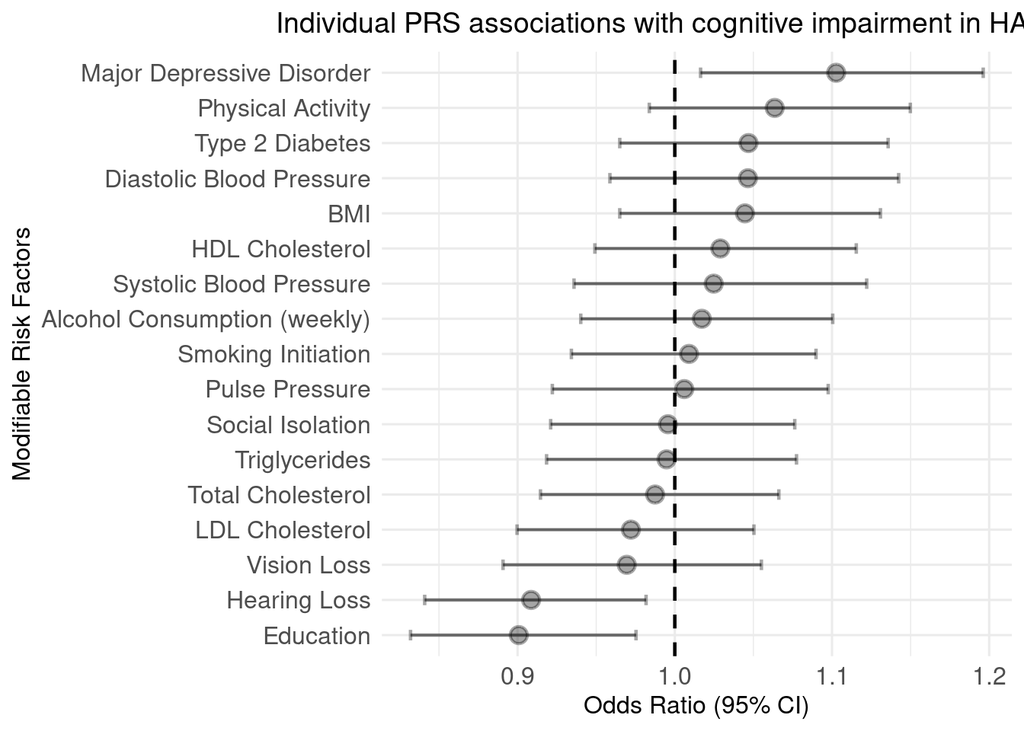

```r
plot_total <- all_results %>%
  dplyr::filter(sex_strata == "Total") %>%
  dplyr::mutate(
    Trait = factor(Trait, levels = trait_order),
    sig = ifelse(p_adj_fdr < 0.05, "significant", "non-significant")
  )

p_total <- ggplot(
  plot_total,
  aes(
    x = Trait,
    y = estimate_or,
    ymin = conf.low_or,
    ymax = conf.high_or,
    alpha = sig
  )
) +
  geom_pointrange(size = 0.8) +
  geom_errorbar(width = 0.3, linewidth = 0.8) +
  geom_hline(yintercept = 1, linetype = "dashed", color = "black", linewidth = 0.8) +
  coord_flip() +
  scale_alpha_manual(values = c("significant" = 1, "non-significant" = 0.35)) +
  labs(
    x = "Modifiable Risk Factors",
    y = "Odds Ratio (95% CI)",
    title = "Individual PRS associations with cognitive impairment in HABS-HD"
  ) +
  guides(alpha = "none") +
  theme(
    axis.title = element_text(size = 12),
    axis.text = element_text(size = 12),
    axis.text.y = element_text(size = 12),
    plot.title = element_text(size = 14, hjust = 0.5)
  )

p_total
```

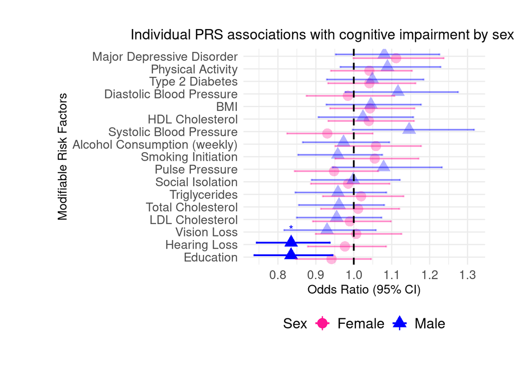

```r
plot_sex <- all_results %>%
  dplyr::filter(sex_strata %in% c("Female", "Male")) %>%
  dplyr::mutate(
    Trait = factor(Trait, levels = trait_order),
    signif = dplyr::case_when(
      p_adj_fdr < 0.001 ~ "***",
      p_adj_fdr < 0.01 ~ "**",
      p_adj_fdr < 0.05 ~ "*",
      TRUE ~ ""
    ),
    star_vjust = if_else(sex_strata == "Female", 2, -1),
    sig = if_else(p_adj_fdr < 0.05, "significant", "non-significant")
  )

p_sex <- ggplot(
  plot_sex,
  aes(
    x = Trait,
    y = estimate_or,
    ymin = conf.low_or,
    ymax = conf.high_or,
    color = sex_strata,
    shape = sex_strata,
    alpha = sig
  )
) +
  geom_pointrange(position = position_dodge(width = 0.6), size = 1) +
  geom_errorbar(width = 0.3, position = position_dodge(width = 0.6), linewidth = 0.8) +
  geom_text(
    aes(label = signif, vjust = star_vjust),
    position = position_dodge(width = 0.6),
    show.legend = FALSE
  ) +
  geom_hline(yintercept = 1, linetype = "dashed", color = "black", linewidth = 0.8) +
  coord_flip() +
  scale_color_manual(values = c("Female" = "deeppink", "Male" = "blue")) +
  scale_shape_manual(values = c("Female" = 16, "Male" = 17)) +
  scale_alpha_manual(values = c("significant" = 1, "non-significant" = 0.3)) +
  labs(
    x = "Modifiable Risk Factors",
    y = "Odds Ratio (95% CI)",
    title = "Individual PRS associations with cognitive impairment by sex in HABS-HD",
    color = "Sex",
    shape = "Sex"
  ) +
  guides(
    color = guide_legend(override.aes = list(shape = c(16, 17), alpha = 1)),
    shape = "none",
    alpha = "none"
  ) +
  theme(
    axis.title = element_text(size = 12),
    axis.text = element_text(size = 12),
    axis.text.y = element_text(size = 12),
    legend.title = element_text(size = 14),
    legend.text = element_text(size = 14),
    plot.title = element_text(size = 14, hjust = 0.5),
    legend.position = "bottom",
    legend.direction = "horizontal",
    plot.margin = margin(1, 1, 1, 2, "cm")
  )

p_sex
```

```r
sample_size_table <- sample_size_df %>%
  dplyr::arrange(sex_strata)

sample_size_table
```

```
## # A tibble: 3 × 4
##   sex_strata n_total n_cases n_controls
##   <chr>        <int>   <int>      <int>
## 1 Female        1981     450       1531
## 2 Male          1226     413        813
## 3 Total         3207     863       2344
```

```r
sample_size_gt <- sample_size_table %>%
  gt() %>%
  tab_header(
    title = "Table 2. Sample-size summary for HABS-HD individual PRS analyses"
  )

sample_size_gt
```

Table 2. Sample-size summary for HABS-HD individual PRS analyses

| sex_strata | n_total | n_cases | n_controls |
| --- | --- | --- | --- |
| Female | 1981 | 450 | 1531 |
| Male | 1226 | 413 | 813 |
| Total | 3207 | 863 | 2344 |

```r
results_gt <- results_table %>%
  gt() %>%
  tab_header(
    title = "Table 3. HABS-HD individual PRS association results"
  )

results_gt
```

Table 3. HABS-HD individual PRS association results

| Trait | sex_strata | Odds Ratio (95% CI) | P Value | FDR |
| --- | --- | --- | --- | --- |
| Education | Female | 0.941 (0.847–1.046) | 2.61e-01 | 8.20e-01 |
| Education | Male | 0.835 (0.738–0.944) | 3.99e-03 | 3.39e-02 |
| Education | Total | 0.901 (0.832–0.975) | 1.00e-02 | 1.06e-01 |
| Hearing Loss | Female | 0.977 (0.879–1.086) | 6.61e-01 | 8.97e-01 |
| Hearing Loss | Male | 0.835 (0.744–0.937) | 2.10e-03 | 3.39e-02 |
| Hearing Loss | Total | 0.909 (0.841–0.982) | 1.52e-02 | 1.06e-01 |
| Vision Loss | Female | 1.006 (0.899–1.126) | 9.13e-01 | 9.13e-01 |
| Vision Loss | Male | 0.930 (0.816–1.059) | 2.71e-01 | 5.75e-01 |
| Vision Loss | Total | 0.969 (0.891–1.055) | 4.72e-01 | 8.30e-01 |
| LDL Cholesterol | Female | 0.990 (0.892–1.098) | 8.44e-01 | 8.97e-01 |
| LDL Cholesterol | Male | 0.955 (0.849–1.073) | 4.39e-01 | 6.15e-01 |
| LDL Cholesterol | Total | 0.972 (0.900–1.050) | 4.73e-01 | 8.30e-01 |
| Total Cholesterol | Female | 1.011 (0.913–1.120) | 8.29e-01 | 8.97e-01 |
| Total Cholesterol | Male | 0.961 (0.855–1.080) | 5.07e-01 | 6.15e-01 |
| Total Cholesterol | Total | 0.987 (0.915–1.066) | 7.47e-01 | 9.13e-01 |
| Triglycerides | Female | 1.019 (0.918–1.132) | 7.21e-01 | 8.97e-01 |
| Triglycerides | Male | 0.958 (0.846–1.086) | 5.06e-01 | 6.15e-01 |
| Triglycerides | Total | 0.995 (0.918–1.077) | 8.97e-01 | 9.13e-01 |
| Social Isolation | Female | 0.985 (0.887–1.095) | 7.82e-01 | 8.97e-01 |
| Social Isolation | Male | 0.999 (0.889–1.122) | 9.80e-01 | 9.80e-01 |
| Social Isolation | Total | 0.996 (0.921–1.076) | 9.13e-01 | 9.13e-01 |
| Pulse Pressure | Female | 0.948 (0.844–1.065) | 3.68e-01 | 8.20e-01 |
| Pulse Pressure | Male | 1.079 (0.944–1.233) | 2.66e-01 | 5.75e-01 |
| Pulse Pressure | Total | 1.006 (0.922–1.098) | 8.93e-01 | 9.13e-01 |
| Smoking Initiation | Female | 1.055 (0.951–1.171) | 3.11e-01 | 8.20e-01 |
| Smoking Initiation | Male | 0.958 (0.853–1.075) | 4.66e-01 | 6.15e-01 |
| Smoking Initiation | Total | 1.009 (0.934–1.090) | 8.19e-01 | 9.13e-01 |
| Alcohol Consumption (weekly) | Female | 1.058 (0.951–1.178) | 2.99e-01 | 8.20e-01 |
| Alcohol Consumption (weekly) | Male | 0.973 (0.865–1.094) | 6.47e-01 | 7.33e-01 |
| Alcohol Consumption (weekly) | Total | 1.017 (0.940–1.100) | 6.72e-01 | 9.13e-01 |
| Systolic Blood Pressure | Female | 0.930 (0.824–1.050) | 2.43e-01 | 8.20e-01 |
| Systolic Blood Pressure | Male | 1.146 (0.997–1.317) | 5.54e-02 | 3.14e-01 |
| Systolic Blood Pressure | Total | 1.025 (0.936–1.122) | 5.97e-01 | 9.13e-01 |
| HDL Cholesterol | Female | 1.040 (0.933–1.159) | 4.82e-01 | 8.20e-01 |
| HDL Cholesterol | Male | 1.024 (0.907–1.157) | 7.00e-01 | 7.44e-01 |
| HDL Cholesterol | Total | 1.029 (0.949–1.115) | 4.88e-01 | 8.30e-01 |
| BMI | Female | 1.043 (0.937–1.160) | 4.41e-01 | 8.20e-01 |
| BMI | Male | 1.045 (0.928–1.178) | 4.69e-01 | 6.15e-01 |
| BMI | Total | 1.045 (0.965–1.131) | 2.81e-01 | 7.51e-01 |
| Diastolic Blood Pressure | Female | 0.985 (0.875–1.108) | 7.95e-01 | 8.97e-01 |
| Diastolic Blood Pressure | Male | 1.116 (0.978–1.275) | 1.04e-01 | 4.43e-01 |
| Diastolic Blood Pressure | Total | 1.047 (0.959–1.142) | 3.09e-01 | 7.51e-01 |
| Type 2 Diabetes | Female | 1.041 (0.932–1.163) | 4.75e-01 | 8.20e-01 |
| Type 2 Diabetes | Male | 1.049 (0.929–1.184) | 4.43e-01 | 6.15e-01 |
| Type 2 Diabetes | Total | 1.047 (0.965–1.136) | 2.70e-01 | 7.51e-01 |
| Physical Activity | Female | 1.041 (0.939–1.154) | 4.42e-01 | 8.20e-01 |
| Physical Activity | Male | 1.089 (0.965–1.229) | 1.69e-01 | 5.74e-01 |
| Physical Activity | Total | 1.064 (0.984–1.150) | 1.21e-01 | 5.16e-01 |
| Major Depressive Disorder | Female | 1.112 (0.999–1.237) | 5.29e-02 | 8.20e-01 |
| Major Depressive Disorder | Male | 1.080 (0.952–1.226) | 2.30e-01 | 5.75e-01 |
| Major Depressive Disorder | Total | 1.103 (1.016–1.196) | 1.87e-02 | 1.06e-01 |

```r
flextable::save_as_docx(
  "HABS-HD Baseline Table 1" = baseline_table1_flex,
  path = file.path(out_tbl_dir, "habshd_individual_prs_baseline_table1.docx")
)

gt::gtsave(
  as_gt(baseline_table1),
  filename = file.path(out_tbl_dir, "habshd_individual_prs_baseline_table1.rtf")
)

saveRDS(final_df, file.path(out_rds_dir, "habshd_individual_prs_analytic_dataset.rds"))
saveRDS(all_results, file.path(out_rds_dir, "habshd_individual_prs_results.rds"))
saveRDS(sample_size_df, file.path(out_rds_dir, "habshd_individual_prs_sample_sizes.rds"))

write.csv(results_table, file.path(out_tbl_dir, "habshd_individual_prs_results.csv"), row.names = FALSE)
write.csv(sample_size_table, file.path(out_tbl_dir, "habshd_individual_prs_sample_sizes.csv"), row.names = FALSE)
xlsx_file <- file.path(out_tbl_dir, "habshd_individual_prs_results.xlsx")

wb <- openxlsx::createWorkbook()

openxlsx::addWorksheet(wb, "Baseline_Table1")
openxlsx::writeData(wb, "Baseline_Table1", baseline_table_data)

openxlsx::addWorksheet(wb, "Sample_Sizes")
openxlsx::writeData(wb, "Sample_Sizes", sample_size_table)

openxlsx::addWorksheet(wb, "Main_Results")
openxlsx::writeData(wb, "Main_Results", results_table)

openxlsx::addWorksheet(wb, "Raw_Model_Results")
openxlsx::writeData(wb, "Raw_Model_Results", all_results)

openxlsx::saveWorkbook(wb, xlsx_file, overwrite = TRUE)

cat("Workbook written to:", xlsx_file, "\n")
```

```
## Workbook written to: results/tables/habshd_individual_prs_results.xlsx
```

```r
gt::gtsave(
  sample_size_gt,
  filename = file.path(out_tbl_dir, "habshd_individual_prs_sample_sizes.html")
)
gt::gtsave(
  gt::gt(results_table) %>%
    tab_header(title = "Table 3. HABS-HD individual PRS association results"),
  filename = file.path(out_tbl_dir, "habshd_individual_prs_results.html")
)

gt::gtsave(
  as_gt(baseline_table1),
  filename = file.path(out_tbl_dir, "habshd_individual_prs_baseline_table1.html")
)

ggsave(
  filename = file.path(out_fig_dir, "habshd_individual_prs_total.png"),
  plot = p_total,
  width = 10,
  height = 6,
  dpi = 300
)

ggsave(
  filename = file.path(out_fig_dir, "habshd_individual_prs_by_sex.png"),
  plot = p_sex,
  width = 12,
  height = 14,
  dpi = 600
)

stopifnot(nrow(all_results) == length(prs_vars) * 3)
stopifnot(nrow(sample_size_df) == 3)

cat("Finished successfully.\n")
```

```
## Finished successfully.
```